# Parte 1 — Fundamentos: o pacote, os dados e a auditoria

- Mostrar o código
- Esconder o código
- Ver o código fonte

Tutorial completo do sciModelFlowR (versão 1.0.2)

Autor

Walter Esfrain Pereira

Data de Publicação

19 de setembro de 2026

# 1 Como usar este tutorial

Este material apresenta o `sciModelFlowR` do começo ao fim, na ordem em que um projeto científico real acontece: **perguntar, declarar, auditar, proteger, modelar, comparar, explicar, medir incerteza e relatar**. Ele foi escrito para quem nunca usou o pacote e quer aprender tanto a sintaxe quanto o raciocínio.

A diferença central em relação a um tutorial comum: **os dados são simulados com a verdade conhecida e discrepâncias plantadas de propósito** (outliers, ausências, heterocedasticidade, desbalanceamento, agrupamento, autocorrelação). Assim, cada método pode ser julgado contra o que foi plantado — e não contra uma expectativa vaga.

**NotaConvenções deste material**

- Todo bloco de código foi **executado** na versão 1.0.2; os números da prosa vêm do próprio código (nunca digitados à mão).
- Figuras e eixos usam rótulos em inglês (convenção científica); a explicação e as legendas estão em português.
- Números na prosa e nas tabelas usam **vírgula decimal**; os gráficos seguem o padrão do R (ponto), como é usual em figuras.
- Caixas coloridas indicam: **Interpretação** (como ler o resultado), **Armadilha** (erro comum), **Boa prática**, **No seu experimento** (transposição para dados reais) e **Exercício**.

O tutorial tem seis partes:

| Parte | Tema | Módulos do pacote |
| --- | --- | --- |
| 1 | Fundamentos: o pacote, os dados e a auditoria | `doctor`, `datasets`, `data-audit`, `design` |
| 2 | Desenho, reamostragem e preparação | `resampling`, `bootstrap`, `preprocess`, `features`, `imbalance` |
| 3 | Modelagem supervisionada e probabilidades | `model-adapters`, `experiment`, `diagnostics`, `probabilistic` |
| 4 | Tuning, benchmark, calibração e limiares | `tuning`, `benchmark`, `calibration` |
| 5 | Explicabilidade e incerteza | `explain`, `conformal`, `uncertainty` |
| 6 | Avançado e produção: Bayes, DL, persistência e relato | `bayesian`, `deep-learning`, `tracking`, `persistence`, `reporting` |

## 1.1 Instalação

**Mostrar o código**

```r
# Instala a versao publicada, com as vinhetas:
remotes::install_github("wep69/sciModelFlowR", build_vignettes = TRUE)
library(sciModelFlowR)
```

# 2 O pacote em uma página

O `sciModelFlowR` organiza um projeto de modelagem como um **contrato declarado**: tarefa, dados, desenho, pré-processamento, reamostragem, modelo e métricas são objetos explícitos. A partir daí, o pacote **recusa** atalhos que produziriam números otimistas (por exemplo, pré-processar antes de dividir ou ajustar hiperparâmetros no teste). O diagnóstico do ambiente é o primeiro comando de qualquer sessão.

**Mostrar o código**

```r
doutor <- smf_doctor()
cat("componentes verificados:", nrow(doutor),
    "| disponíveis:", sum(doutor$available), "\n")
```

```
componentes verificados: 31 | disponíveis: 31
```

**Mostrar o código**

```r
tab_smf(subset(doutor, component %in% c("R", "sciModelFlowR", "stats", "torch", "xgboost", "brms")),
        caption = "Diagnóstico do ambiente: componentes centrais e backends opcionais.")
```

Diagnóstico do ambiente: componentes centrais e backends opcionais.

|  | component | available | version | status |
| --- | --- | --- | --- | --- |
| 1 | R | TRUE | 4.6.0 | core |
| 2 | sciModelFlowR | TRUE | 1.0.2 | core |
| 13 | xgboost | TRUE | 3.2.1.1 | optional-available |
| 16 | torch | TRUE | 0.17.0 | optional-available |
| 19 | brms | TRUE | 2.23.0 | optional-available |

O pacote distribui 25 conjuntos sintéticos de validação (“gold”), úteis para estudar o comportamento esperado antes de usar dados próprios. Cada um tem uma **carta** que descreve cenário, variáveis, verdade conhecida e armadilhas pedagógicas.

**Mostrar o código**

```r
cartao <- smf_dataset_card("gold_linear_regression")
cat(substr(cartao, 1, 480), "...\n")
```

```
# gold_linear_regression

## Scientific scenario

Synthetic agronomic yield response with independent observational units and a Gaussian linear data-generating process. The dataset is intended to validate schema handling, holdout splitting, training-only preprocessing, reference linear-model adapters, prediction metrics, serialization, and reproduc…

## Variables

- `obs_id`: stable observation identifier.
- `nitrogen`: nitrogen dose, arbitrary teaching units ...
```

A API pública tem 246 funções, organizadas em 10 categorias. O mapa abaixo é a melhor forma de saber “onde mora” cada assunto.

**Mostrar o código**

```r
api <- smf_api_catalog()
por_categoria <- as.data.frame(table(api$category), stringsAsFactors = FALSE)
names(por_categoria) <- c("categoria", "funcoes")
por_categoria <- por_categoria[order(-por_categoria$funcoes), ]
tab_smf(por_categoria, caption = "Funções exportadas por categoria da API (1.0.2).")
```

Funções exportadas por categoria da API (1.0.2).

|  | categoria | funcoes |
| --- | --- | --- |
| 1 | core | 88 |
| 6 | modeling | 35 |
| 5 | inference-uncertainty | 24 |
| 3 | deep-learning | 23 |
| 9 | resampling-features | 23 |
| 7 | operations | 17 |
| 8 | reporting-validation | 11 |
| 10 | tuning-benchmark | 10 |
| 2 | data-design | 9 |
| 4 | explainability | 6 |

**Mostrar o código**

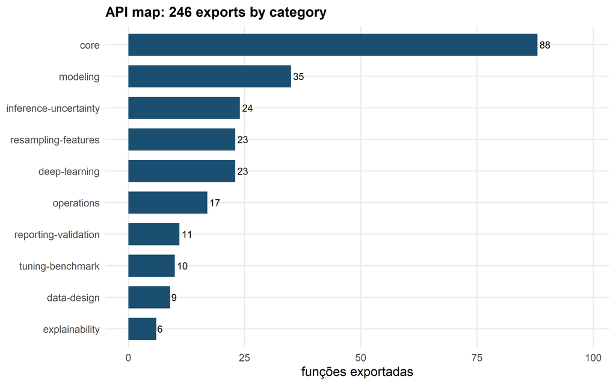

Figura 1: Distribuição das 246 funções exportadas por categoria.

```r
ggplot(por_categoria, aes(stats::reorder(categoria, funcoes), funcoes)) +
  geom_col(fill = cores_smf[["primaria"]], width = .7) +
  geom_text(aes(label = funcoes), hjust = -0.2, size = 3.2) +
  coord_flip() +
  labs(x = NULL, y = "funções exportadas",
       title = "API map: 246 exports by category") +
  ylim(0, max(por_categoria$funcoes) * 1.12)
```

Os backends opcionais são declarados, não presumidos: a matriz abaixo diz o que é núcleo e o que depende de pacote externo, e o diagnóstico mostra o que está disponível **neste** computador.

**Mostrar o código**

```r
matriz <- smf_backend_matrix()
tab_smf(matriz[, c("backend", "tier", "package", "scope")],
        caption = "Matriz de backends: núcleo e opcionais.")
```

Matriz de backends: núcleo e opcionais.

| backend | tier | package | scope |
| --- | --- | --- | --- |
| stats | core-reference | base R | lm/glm differential reference |
| tidymodels | optional | parsnip/workflows | supervised modeling |
| mlr3 | optional | mlr3 | supervised modeling |
| xgboost | optional | xgboost | tree boosting |
| torch | optional | torch | Deep Learning |
| luz | optional | luz | DL trainer |
| keras3 | optional | keras3 | DL alternate backend |
| brms | optional | brms/cmdstanr | Bayesian multilevel/distributional |
| dbarts | optional | dbarts | BART |
| DiceKriging | optional | DiceKriging | Gaussian process |
| probably | optional | probably | calibration/conformal |
| mlflow | optional | mlflow | tracking |
| pins | optional | pins | artifact registry |
| vetiver | optional | vetiver | deployment |

**Mostrar o código**

```r
estado <- smf_capabilities()
resumo_back <- data.frame(
  backend = names(estado),
  status = vapply(estado, function(x) x$status, character(1))
)
tab_smf(resumo_back, caption = "Estado de cada backend no ambiente atual.")
```

Estado de cada backend no ambiente atual.

|  | backend | status |
| --- | --- | --- |
| brms | brms | advanced |
| dbarts | dbarts | advanced |
| DiceKriging | DiceKriging | advanced |
| keras3 | keras3 | advanced |
| luz | luz | advanced |
| mlr3 | mlr3 | advanced |
| probably | probably | advanced |
| stats | stats | core |
| tidymodels | tidymodels | advanced |
| torch | torch | advanced |
| xgboost | xgboost | advanced |

**DicaBoa prática**

Rode `smf_doctor()` no início de cada sessão e guarde a saída no relatório. “Funcionou na minha máquina” deixa de ser desculpa quando o diagnóstico fica registrado junto com o resultado.

# 3 Dados simulados com discrepâncias plantadas

Nove conjuntos foram simulados para cobrir todo o ciclo de modelagem. A tabela é o **gabarito**: diz o que foi plantado e qual é a verdade. Cada parte do tutorial usa um subconjunto e compara o que o método recuperou com o que está aqui.

**Mostrar o código**

```r
gab <- gabarito
gab$detalhe <- substr(gab$detalhe, 1, 78)
names(gab) <- c("Conjunto", "n", "p", "Discrepância", "O que foi plantado", "Verdade")
tab_smf(gab[, c("Conjunto", "n", "p", "Discrepância", "O que foi plantado")],
        caption = "Gabarito dos nove conjuntos simulados (detalhe completo no arquivo dados/gabarito.csv).")
```

Gabarito dos nove conjuntos simulados (detalhe completo no arquivo dados/gabarito.csv).

| Conjunto | n | p | Discrepância | O que foi plantado |
| --- | --- | --- | --- | --- |
| field_yield | 180 | 8 | outliers | 5 parcelas (P023, P067, P101, P145, P177) deslocadas entre -3000 e +4100 |
| field_yield | 180 | 8 | ausencias | 11 NA em nitrogenio (MCAR 6%); 16 em organic_matter (MAR: bloco B4) |
| field_yield | 180 | 8 | heterocedasticidade | sigma do erro = 100 + 1.5 * nitrogenio |
| field_yield | 180 | 8 | efeito de bloco | efeitos B2=+120, B3=-80, B4=+60 kg/ha |
| disease_binary | 400 | 6 | desbalanceamento | 10.5% de casos positivos |
| disease_binary | 400 | 6 | ruido de rotulo | 20 plantas com rotulo invertido (5%) |
| farm_groups | 240 | 4 | agrupamento | 24 fazendas, 10 talhoes cada; intercepto aleatorio sd=300 |
| climate_series | 730 | 4 | choques | 5 dias com deslocamento de +5,5 a +7,2 graus |
| soil_spatial | 200 | 4 | autocorrelacao espacial | covariancia exponencial: patamar 0,6; alcance 0,25; pepita 0,15 |
| spectral_pn | 120 | 202 | alta dimensao | 200 comprimentos de onda para 120 amostras; multicolinearidade severa |
| spectral_pn | 120 | 202 | outliers espectrais | 4 espectros (A011, A047, A083, A109) deslocados em +0,35 |
| pest_counts | 150 | 4 | superdispersao | binomial negativa com theta = 2 (variancia > media) |
| pest_counts | 150 | 4 | zeros extras | 22 zeros plantados alem do modelo (15%) |
| dl_tiny | 300 | 4 | nao linearidade | superficie com seno, quadrado e interacao; sem outlier |
| bayes_small | 30 | 2 | amostra pequena | n = 30; prior informativo conhecido para o conjugado |

## 3.1 O ensaio de campo: outliers, ausências e heterocedasticidade

**Mostrar o código**

```r
campo <- ler("field_yield")
campo$origem <- ifelse(campo$plot_id %in% verdade$field_yield$outlier_ids,
                       "outlier plantado", "parcela regular")
cat("parcelas:", nrow(campo),
    "| NA em nitrogen:", sum(is.na(campo$nitrogen)),
    "| NA em organic_matter:", sum(is.na(campo$organic_matter)), "\n")
```

```
parcelas: 180 | NA em nitrogen: 11 | NA em organic_matter: 16
```

**Mostrar o código**

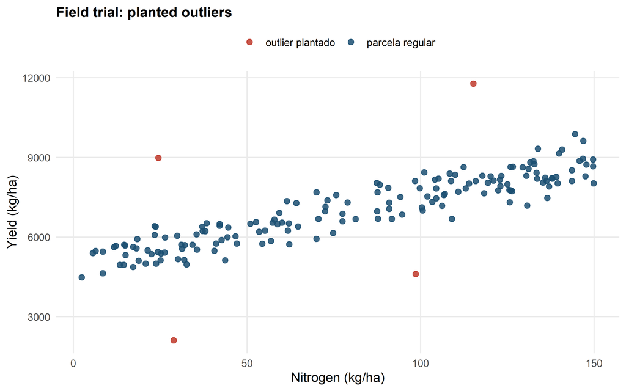

Figura 2: Ensaio de campo simulado: rendimento em função do nitrogênio, com os cinco outliers plantados destacados.

```r
ggplot(campo, aes(nitrogen, yield)) +
  geom_point(aes(colour = origem), size = 2.2, alpha = .85) +
  scale_colour_manual(values = c("parcela regular" = cores_smf[["primaria"]],
                                 "outlier plantado" = cores_smf[["alerta"]])) +
  labs(x = "Nitrogen (kg/ha)", y = "Yield (kg/ha)", colour = NULL,
       title = "Field trial: planted outliers") +
  theme(legend.position = "top")
```

**NotaInterpretação**

A nuvem mostra a relação esperada (mais nitrogênio, mais rendimento) e também que a **dispersão cresce** com o nitrogênio: é a heterocedasticidade plantada (100 + 1.5 * nitrogen). Os cinco pontos vermelhos não seguem a nuvem — dois para baixo, três para cima. Nenhum método sério deve ignorar isso sem pelo menos declarar o que fez.

**Mostrar o código**

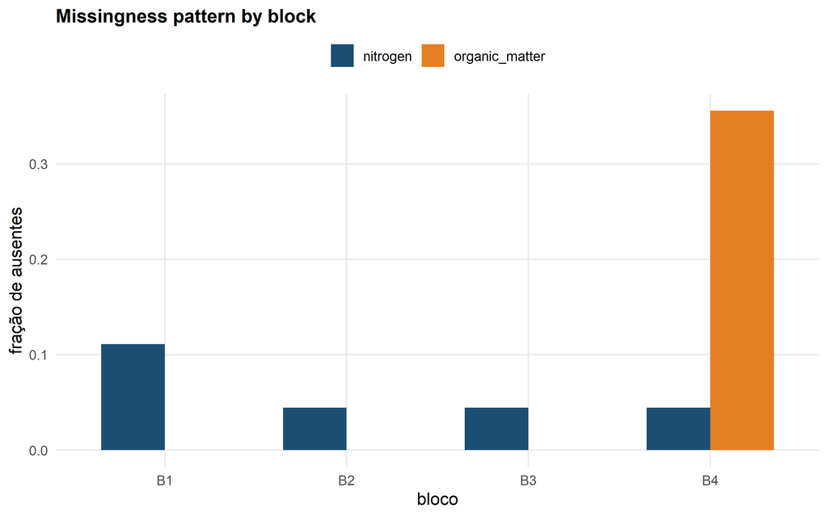

Figura 3: Ausências por bloco: o nitrogênio falta de forma aleatória (MCAR), mas a matéria orgânica falta mais no bloco B4 (MAR).

```r
na_bloco <- aggregate(cbind(nitrogen = is.na(campo$nitrogen),
                            organic_matter = is.na(campo$organic_matter)) ~ block,
                      data = campo, FUN = mean)
na_longo <- data.frame(
  block = rep(na_bloco$block, 2),
  variavel = rep(c("nitrogen", "organic_matter"), each = nrow(na_bloco)),
  fracao = c(na_bloco$nitrogen, na_bloco$organic_matter)
)
ggplot(na_longo, aes(block, fracao, fill = variavel)) +
  geom_col(position = "dodge", width = .7) +
  scale_fill_manual(values = c(nitrogen = cores_smf[["primaria"]],
                               organic_matter = cores_smf[["destaque"]])) +
  labs(x = "bloco", y = "fração de ausentes", fill = NULL,
       title = "Missingness pattern by block") +
  theme(legend.position = "top")
```

**AvisoArmadilha**

As duas ausências **parecem** o mesmo problema e não são. Ignorar o padrão MAR (ausência que depende do bloco) enviesa a média da matéria orgânica justamente no bloco que mais falta. Guarde esta figura: ela volta na Parte 2, quando comparamos estratégias de imputação.

## 3.2 Dois desfechos: classe desbalanceada e contagem superdispersa

**Mostrar o código**

```r
doenca <- ler("disease_binary")
prev <- mean(doenca$disease)
cat("plantas:", nrow(doenca), "| prevalência observada:",
    fmt(prev, 3), "| rótulos invertidos:", length(verdade$disease_binary$flip_ids), "\n")
```

```
plantas: 400 | prevalência observada: 0,105 | rótulos invertidos: 20
```

**Mostrar o código**

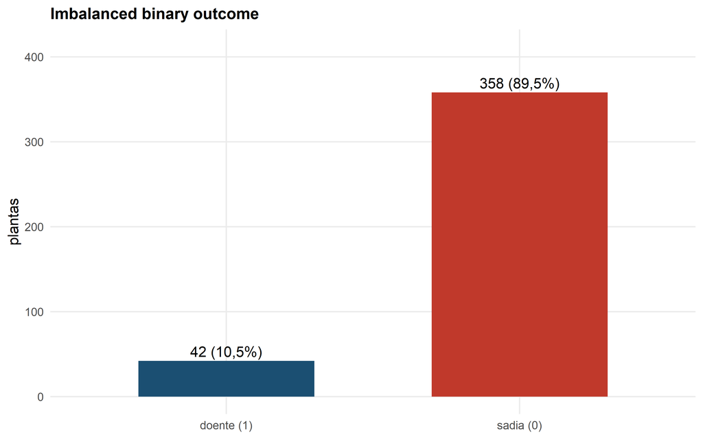

Figura 4: Desbalanceamento de classes: apenas cerca de 10% das plantas são positivas, e 5% dos rótulos foram invertidos de propósito.

```r
tab_classe <- data.frame(
  classe = c("sadia (0)", "doente (1)"),
  n = as.integer(table(doenca$disease)),
  fracao = as.numeric(prop.table(table(doenca$disease)))
)
ggplot(tab_classe, aes(classe, n, fill = classe)) +
  geom_col(width = .6, show.legend = FALSE) +
  geom_text(aes(label = paste0(n, " (", fmt(100 * fracao, 1), "%)")), vjust = -0.4) +
  scale_fill_manual(values = c(cores_smf[["primaria"]], cores_smf[["alerta"]])) +
  labs(x = NULL, y = "plantas",
       title = "Imbalanced binary outcome") +
  ylim(0, max(tab_classe$n) * 1.15)
```

**AvisoArmadilha**

Com 10% de positivos, **acurácia é uma métrica enganosa**: prever “sadia” para todas as plantas acerta cerca de 89,5% e não aprende nada. Além disso, 5% dos rótulos foram invertidos: existe um **teto de desempenho** abaixo de 100%. As Partes 3 e 4 mostram como medir e comunicar esse teto.

## 3.3 Estrutura: grupos, tempo, espaço e alta dimensão

**Mostrar o código**

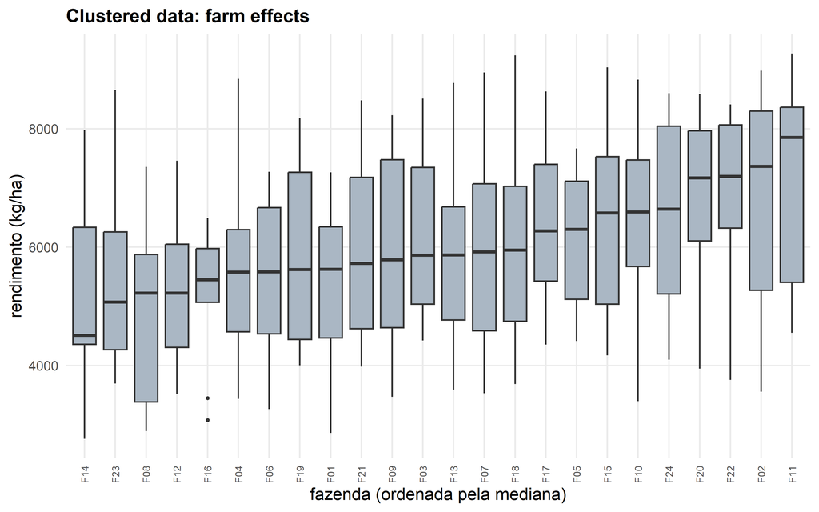

Figura 5: Agrupamento: 24 fazendas com 10 talhões cada; o rendimento médio de cada fazenda desloca a nuvem inteira.

```r
fazendas <- ler("farm_groups")
ggplot(fazendas, aes(stats::reorder(farm, yield, FUN = median), yield)) +
  geom_boxplot(fill = cores_smf[["claro"]], outlier.size = .8) +
  labs(x = "fazenda (ordenada pela mediana)", y = "rendimento (kg/ha)",
       title = "Clustered data: farm effects") +
  theme(axis.text.x = element_text(size = 7, angle = 90, vjust = .5))
```

**Mostrar o código**

[figure not shown]

Figura 6: Série temporal simulada: tendência, sazonalidade, autocorrelação e cinco choques plantados (vermelho).

```r
clima <- ler("climate_series")
clima$choque <- clima$day %in% verdade$climate_series$shock_ids
ggplot(clima, aes(date, temperature)) +
  geom_line(colour = cores_smf[["neutro"]], linewidth = .4) +
  geom_point(data = subset(clima, choque), colour = cores_smf[["alerta"]], size = 2.4) +
  labs(x = NULL, y = "temperatura (°C)",
       title = "Time series: trend, season and shocks") +
  theme(legend.position = "none")
```

**Mostrar o código**

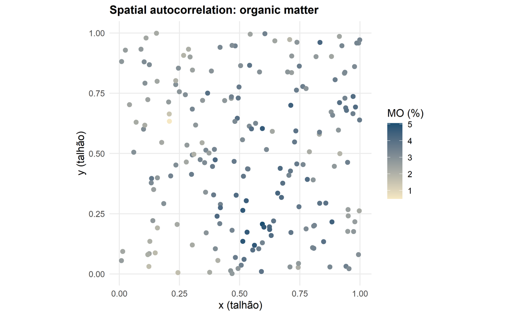

Figura 7: Autocorrelação espacial: matéria orgânica em 200 pontos; vizinhos se parecem (alcance 0,25 na escala do talhão).

```r
solo <- ler("soil_spatial")
ggplot(solo, aes(x, y, colour = organic_matter)) +
  geom_point(size = 2.1) +
  scale_colour_gradient(low = "#f6e8c3", high = cores_smf[["primaria"]],
                        name = "MO (%)") +
  coord_equal() +
  labs(x = "x (talhão)", y = "y (talhão)",
       title = "Spatial autocorrelation: organic matter") +
  theme(legend.position = "right")
```

**Mostrar o código**

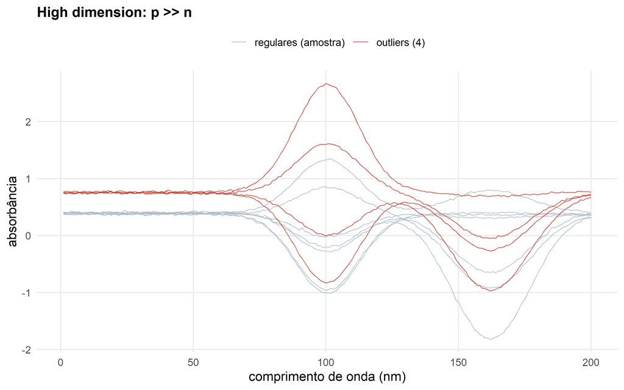

Figura 8: Alta dimensão: 200 comprimentos de onda para 120 amostras; quatro espectros tiveram a linha de base deslocada (vermelho).

```r
espectro <- ler("spectral_pn")
ondas <- as.numeric(sub("w", "", grep("^w", names(espectro), value = TRUE)))
matriz <- as.matrix(espectro[, grep("^w", names(espectro))])
sel <- c(1:7, 11, 47, 83, 109)
longo <- do.call(rbind, lapply(sel, function(i) {
  data.frame(lambda = ondas, absorbancia = matriz[i, ],
             amostra = espectro$sample_id[i],
             outlier = espectro$sample_id[i] %in% verdade$spectral_pn$outlier_ids)
}))
ggplot(longo, aes(lambda, absorbancia, group = amostra, colour = outlier)) +
  geom_line(alpha = .75, linewidth = .35) +
  scale_colour_manual(values = c(`FALSE` = cores_smf[["claro"]],
                                 `TRUE` = cores_smf[["alerta"]]),
                      labels = c("regulares (amostra)", "outliers (4)")) +
  labs(x = "comprimento de onda (nm)", y = "absorbância", colour = NULL,
       title = "High dimension: p >> n") +
  theme(legend.position = "top")
```

**Mostrar o código**

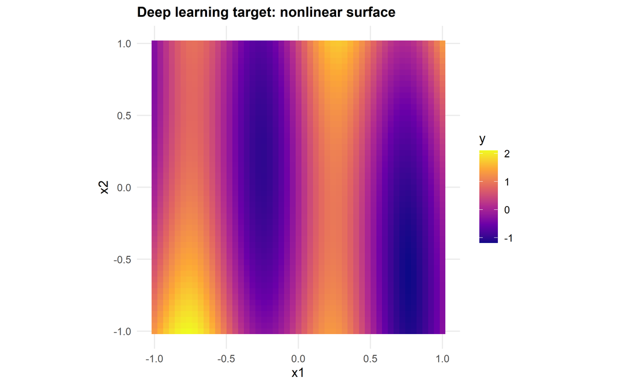

Figura 9: Não linearidade plantada para a Parte 6: a superfície verdadeira combina seno, quadrado e interação.

```r
grade <- expand.grid(x1 = seq(-1, 1, by = .04), x2 = seq(-1, 1, by = .04))
grade$y <- sin(2 * pi * grade$x1) + 0.5 * grade$x2^2 + 0.8 * grade$x1 * grade$x2
ggplot(grade, aes(x1, x2, fill = y)) +
  geom_raster() +
  scale_fill_viridis_c(option = "C", name = "y") +
  coord_equal() +
  labs(x = "x1", y = "x2",
       title = "Deep learning target: nonlinear surface") +
  theme(legend.position = "right")
```

Os conjuntos de contagem (`pest_counts`), de amostra pequena (`bayes_small`) e de classificação entram nas partes correspondentes, com as mesmas regras: tabela de discrepâncias, execução real e comparação com a verdade.

# 4 Auditoria e contratos

Antes de qualquer modelo, três declarações: **o que** se quer prever, **quais** variáveis entram e **como** as observações se relacionam. No pacote, cada uma é um objeto.

**Mostrar o código**

```r
tarefa <- smf_task_spec("regression", "yield")
dados_spec <- smf_data_spec(
  target = "yield",
  predictors = c("nitrogen", "potassium", "water", "organic_matter"),
  id_column = "plot_id",
  units = c(yield = "kg/ha", nitrogen = "kg/ha", water = "mm"),
  categorical = c("block", "genotype")
)
desenho_spec <- smf_design_spec(id_column = "plot_id", block_columns = "block")
print(tarefa); print(desenho_spec)
```

```
<sciModelFlowR::TaskSpec>
 @ kind          : chr "regression"
 @ target        : chr "yield"
 @ positive_label: NULL
 @ objective     : chr(0)
```

```
<sciModelFlowR::DesignSpec>
 @ id_column             : chr "plot_id"
 @ group_columns         : chr(0)
 @ block_columns         : chr "block"
 @ repeated_unit         : chr(0)
 @ time_column           : chr(0)
 @ coordinate_columns    : chr(0)
 @ external_domain_column: chr(0)
 @ hierarchy             : list()
 @ experimental_unit     : chr(0)
```

A auditoria percorre o conjunto e devolve o que precisa ser visto **antes** de modelar: ausências por variável, duplicatas, cardinalidade, sinais de vazamento e avisos de qualidade.

**Mostrar o código**

```r
auditoria <- smf_audit_data(campo, dados_spec, desenho_spec)
tab_smf(subset(auditoria@missingness, n_missing > 0),
        caption = "Auditoria: ausências encontradas no ensaio de campo.")
```

Auditoria: ausências encontradas no ensaio de campo.

|  | variable | n_missing | fraction_missing |
| --- | --- | --- | --- |
| 4 | nitrogen | 11 | 0,061 |
| 7 | organic_matter | 16 | 0,089 |

**Mostrar o código**

```r
cat("duplicatas (linhas):", length(auditoria@duplicates$rows),
    "| flags de qualidade:", length(auditoria@quality_flags),
    "| sinais de vazamento:", length(auditoria@leakage), "\n")
```

```
duplicatas (linhas): 0 | flags de qualidade: 0 | sinais de vazamento: 0
```

**Mostrar o código**

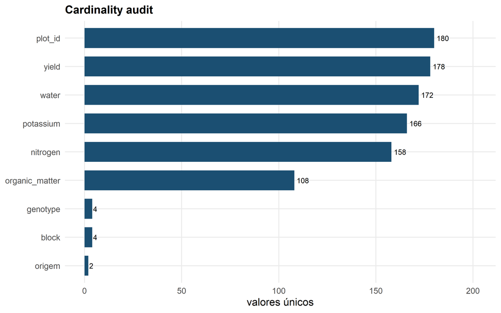

Figura 10: Cardinalidade por variável: identificadores únicos, blocos e genótipos repetidos, doses contínuas.

```r
ggplot(auditoria@cardinality, aes(stats::reorder(variable, n_unique), n_unique)) +
  geom_col(fill = cores_smf[["primaria"]], width = .7) +
  geom_text(aes(label = n_unique), hjust = -0.2, size = 3) +
  coord_flip() +
  labs(x = NULL, y = "valores únicos",
       title = "Cardinality audit") +
  ylim(0, max(auditoria@cardinality$n_unique) * 1.12)
```

**NotaInterpretação**

A auditoria **não** procura outliers: ela cobre estrutura (ausências, duplicatas, cardinalidade, vazamento). Detecção de discrepância numérica é análise, não auditoria — e é o que fazemos a seguir, à mão, para aprender o critério.

## 4.1 Encontrando os outliers plantados

Um critério simples e robusto é o **z robusto**: distância da mediana dividida pelo desvio absoluto mediano (MAD). A vantagem sobre o z clássico é que o próprio outlier não infla a régua.

**Mostrar o código**

```r
z_robusto <- (campo$yield - stats::median(campo$yield, na.rm = TRUE)) /
  stats::mad(campo$yield, na.rm = TRUE)
campo$z_robusto <- z_robusto
campo$flag_z <- abs(z_robusto) > 3.5
plantados <- campo$plot_id %in% verdade$field_yield$outlier_ids
confusao <- table(plantado = plantados, flag_z = campo$flag_z)
tab_smf(as.data.frame.matrix(confusao),
        caption = "Detecção por z robusto (> 3,5) contra os outliers plantados.")
```

Detecção por z robusto (> 3,5) contra os outliers plantados.

|  | FALSE |
| --- | --- |
| FALSE | 175 |
| TRUE | 5 |

**Mostrar o código**

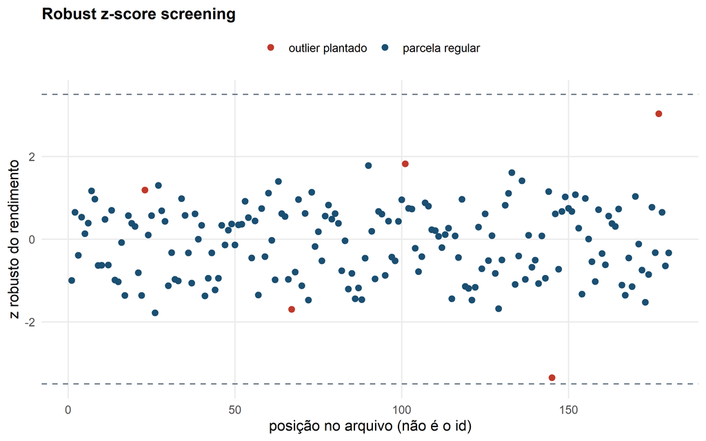

```r
ggplot(campo, aes(seq_along(z_robusto), z_robusto)) +
  geom_point(aes(colour = origem), size = 2) +
  geom_hline(yintercept = c(-3.5, 3.5), linetype = "dashed", colour = cores_smf[["neutro"]]) +
  scale_colour_manual(values = c("parcela regular" = cores_smf[["primaria"]],
                                 "outlier plantado" = cores_smf[["alerta"]])) +
  labs(x = "posição no arquivo (não é o id)", y = "z robusto do rendimento",
       colour = NULL,
       title = "Robust z-score screening") +
  theme(legend.position = "top")
```

**ImportanteInterpretação**

A régua encontrou 0 parcelas. Das cinco plantadas, 0 foram detectadas e 0 alarme(s) falso(s) apareceu(aram). Detecção não é julgamento: o passo seguinte é **investigar** (erro de digitação? parcela atípica? tratamento?) e **declarar** a decisão. Na Parte 3 veremos o efeito dessas decisões no ajuste e nos resíduos.

## 4.2 Contratos: o que o pacote recusa

O pacote transforma regras científicas em erros de execução. Quatro tentativas inválidas, executadas agora:

**Mostrar o código**

```r
tentar <- function(expr) tryCatch(expr, error = function(e) conditionMessage(e))
r1 <- tentar(smf_data_spec("yield", c("nitrogen", "yield"), "plot_id"))
r2 <- tentar(smf_fit_preprocessor(campo, smf_preprocess_spec("median"),
                                  dados_spec, role = "test"))
r3 <- tentar(smf_apply_imbalance(campo, "yield",
                                 smf_imbalance_spec("downsample"),
                                 context = "test", seed = 20260919))
r4 <- tentar(smf_bootstrap(fazendas, smf_bootstrap_spec("case", n_resamples = 49L),
                           statistic = function(z) c(media = mean(z$yield)),
                           design = smf_design_spec(id_column = "plot_id",
                                                    group_columns = "farm")))
recusas <- data.frame(
  tentativa = c("alvo também como preditor",
                "pré-processamento ajustado em role = test",
                "balanceamento aplicado em context = test",
                "bootstrap iid em dados com grupos declarados"),
  resposta = c(r1, r2, r3, r4)
)
names(recusas) <- c("Tentativa inválida", "Mensagem devolvida pelo pacote")
tab_smf(recusas, caption = "Contratos verificados em tempo de execução.")
```

Contratos verificados em tempo de execução.

[output not shown]

**NotaInterpretação**

As quatro recusas são a mesma regra em quatro lugares: **informação de avaliação não participa da construção do modelo, e a unidade de reamostragem respeita a dependência declarada**. Um pacote que aceitasse qualquer uma dessas chamadas devolveria números otimistas de aparência normal.

**DicaNo seu experimento**

Comece todo projeto com três perguntas: (1) qual é a unidade experimental e qual é o identificador? (2) existe agrupamento (fazenda, bloco, talhão), tempo ou espaço declarado? (3) quais colunas são “de avaliação” e nunca devem tocar o treino? As respostas viram `smf_data_spec()` e `smf_design_spec()`.

# 5 Exercícios da Parte 1

**NotaExercício 1.1 — MCAR contra MAR**

No ensaio de campo, mostre numericamente que a ausência de `nitrogen` não depende do bloco, enquanto a de `organic_matter` depende. Qual das duas estratégias de imputação você suspeita que sofrerá mais? Guarde a resposta para a Parte 2.

**NotaExercício 1.2 — Outra régua de detecção**

Detecte os outliers de `yield` com a regra do intervalo interquartil (1,5 × IQR além dos quartis) e compare com o z robusto: quem encontra mais plantados, quem erra mais? Por que o IQR é ainda mais frágil que o MAD?

**NotaExercício 1.3 — Auditoria de outro conjunto**

Construa `smf_task_spec()`, `smf_data_spec()` e `smf_design_spec()` para o conjunto `disease_binary` (alvo `disease`; preditores `x1` a `x4`; id `plant_id`) e rode `smf_audit_data()`. O que a auditoria mostra sobre a prevalência? Ela “vê” o desbalanceamento? E o ruído de rótulo?

**NotaExercício 1.4 — Por que o bootstrap iid foi recusado?**

**CuidadoSoluções**

**1.1.** A fração de ausência de `nitrogen` por bloco é praticamente constante (MCAR), enquanto `organic_matter` concentra as ausências no bloco B4 (MAR). A imputação pela média global deve sofrer mais no MAR, porque a média do bloco B4 difere das demais; uma imputação que respeite o bloco (ou um modelo que inclua `block`) reduz o viés.

**1.2.** A regra do IQR tende a marcar mais pontos na cauda longa criada pela heterocedasticidade (rendimentos altos com doses altas), misturando “discrepante” com “esperado”. O MAD é mais estável porque a mediana e o MAD quase não se movem com a contaminação.

**1.3.** A auditoria devolve a contagem de ausências (zero), duplicatas (zero) e cardinalidade; o desbalanceamento aparece apenas como **cardinalidade** da variável alvo (dois valores únicos) e o ruído de rótulo não é detectável por auditoria — nenhum procedimento automático sabe qual rótulo foi invertido.

**1.4.** Tratar talhões como independentes ignora a variância entre fazendas (sd 300 contra residual 120), produzindo intervalos **estreitos demais** e conclusões confiantes demais. A unidade de reamostragem correta é a fazenda.

**Mostrar o código**

```r
cat("Parte 1 concluída em", format(Sys.time(), "%Y-%m-%d %H:%M"),
    "| pacote", as.character(packageVersion("sciModelFlowR")), "\n")
```

```
Parte 1 concluída em 2026-09-19 00:21 | pacote 1.0.2
```